# Taller Final Estadistica Inferencial

Robert Garcia Rey - Sebastian Carrero

Esta es una libreta de R Markdown. Cuando se ejecuta código dentro de la libreta, los resultados aparecen debajo del código.

#### Inicialmente se hace la carga de librerias

```r
library(readr)
```

```r
library(ggplot2)
library(ggpubr)
library(dplyr)
library(psych)
library(gridExtra)
```

#### Se hace la carga del dataset

```r
data <- read.csv("data_set.csv", sep = ";")
head(data, n = 5)
```

```
##   X experiencia genero salario grado_esc
## 1 1        7.27 female    9.70  Maestria
## 2 2        6.76 female   12.79  Pregrado
## 3 3        6.76 female   15.51  Pregrado
## 4 4        8.67 female   12.22  Maestria
## 5 5        7.50 female    9.12  Maestria
```

##### Análisis descriptivo

```r
summary(data)
```

```
##        X           experiencia        genero             salario
##  Min.   :   1.0   Min.   : 0.000   Length:3294        Min.   : 0.38
##  1st Qu.: 824.2   1st Qu.: 6.250   Class :character   1st Qu.:10.17
##  Median :1647.5   Median : 7.230   Mode  :character   Median :12.35
##  Mean   :1647.5   Mean   : 7.510                      Mean   :12.36
##  3rd Qu.:2470.8   3rd Qu.: 8.498                      3rd Qu.:14.55
##  Max.   :3294.0   Max.   :16.730                      Max.   :25.24
##   grado_esc
##  Length:3294
##  Class :character
##  Mode  :character
##
##
##
```

```r
describe(data)
```

```
##             vars    n    mean     sd  median trimmed     mad  min     max
## X              1 3294 1647.50 951.04 1647.50 1647.50 1220.92 1.00 3294.00
## experiencia    2 3294    7.51   2.30    7.23    7.39    1.63 0.00   16.73
## genero*        3 3294    1.52   0.50    2.00    1.53    0.00 1.00    2.00
## salario        4 3294   12.36   3.31   12.35   12.35    3.25 0.38   25.24
## grado_esc*     5 3294    2.90   0.83    3.00    2.84    0.00 1.00    5.00
##               range  skew kurtosis    se
## X           3293.00  0.00    -1.20 16.57
## experiencia   16.73  0.57     1.33  0.04
## genero*        1.00 -0.09    -1.99  0.01
## salario       24.86  0.06     0.22  0.06
## grado_esc*     4.00  0.58     1.88  0.01
```

#### Se verifica si hay datos nulos

```r
# Identificar valores nulos
nulos <- is.na(data)

# Contar valores nulos
sum(nulos)
```

```
## [1] 0
```

## 1. ANALISIS EXPLORATORIO DE LOS DATOS

### boxplot para las variables experiencia y salario, de acuerdo al género del empleado

#### Se filtra el DataFrame por genero para análizar los datos descriptivos

Dataframa filtrado por genero masculino

```r
data_masc <- data[data$genero == "male", ]
head(data_masc)
```

```
##         X experiencia genero salario grado_esc
## 1570 1570       10.65   male   14.22  Pregrado
## 1571 1571        9.17   male   11.31  Maestria
## 1572 1572        6.62   male   12.12  Pregrado
## 1573 1573        8.23   male   11.58  Pregrado
## 1574 1574        4.50   male   14.31  Pregrado
## 1575 1575        7.44   male    9.35  Pregrado
```

```r
summary(data_masc)
```

```
##        X         experiencia        genero             salario
##  Min.   :1570   Min.   : 0.000   Length:1725        Min.   : 1.66
##  1st Qu.:2001   1st Qu.: 5.940   Class :character   1st Qu.:10.44
##  Median :2432   Median : 7.890   Mode  :character   Median :12.59
##  Mean   :2432   Mean   : 7.991                      Mean   :12.64
##  3rd Qu.:2863   3rd Qu.:10.020                      3rd Qu.:14.80
##  Max.   :3294   Max.   :16.730                      Max.   :24.95
##   grado_esc
##  Length:1725
##  Class :character
##  Mode  :character
##
##
##
```

Dataframa filtrado por genero femenino

```r
data_feme <- data[data$genero == "female", ]
head(data_feme)
```

```
##   X experiencia genero salario grado_esc
## 1 1        7.27 female    9.70  Maestria
## 2 2        6.76 female   12.79  Pregrado
## 3 3        6.76 female   15.51  Pregrado
## 4 4        8.67 female   12.22  Maestria
## 5 5        7.50 female    9.12  Maestria
## 6 6        5.58 female   13.64  Maestria
```

```r
summary(data_feme)
```

```
##        X         experiencia        genero             salario
##  Min.   :   1   Min.   : 3.780   Length:1569        Min.   : 0.38
##  1st Qu.: 393   1st Qu.: 6.350   Class :character   1st Qu.: 9.91
##  Median : 785   Median : 6.990   Mode  :character   Median :12.12
##  Mean   : 785   Mean   : 6.981                      Mean   :12.06
##  3rd Qu.:1177   3rd Qu.: 7.640                      3rd Qu.:14.23
##  Max.   :1569   Max.   :10.340                      Max.   :25.24
##   grado_esc
##  Length:1569
##  Class :character
##  Mode  :character
##
##
##
```

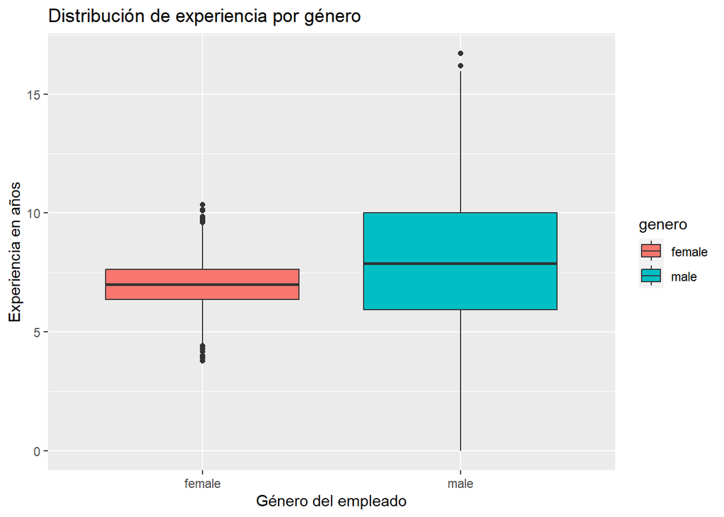

```r
ggplot(data, aes(x = genero, y = experiencia, fill = genero)) +
  geom_boxplot() +
  ggtitle("Distribución de experiencia por género") +
  xlab("Género del empleado") +
  ylab("Experiencia en años")
```

Al analizar la media y la variabilidad de la experiencia en los datos por género, se puede observar que la media de la distribución de la experiencia para el género masculino es de 7.9 años, mientras que para el género femenino es de 6.9 años. Asimismo, se pudo observar que hay mayor variabilidad en la experiencia para el género masculino, con un rango de 16.73 años, mientras que para el género femenino el rango es de 6.56 años. Estos resultados sugieren que existe una diferencia en la experiencia laboral entre hombres y mujeres en la muestra analizada.

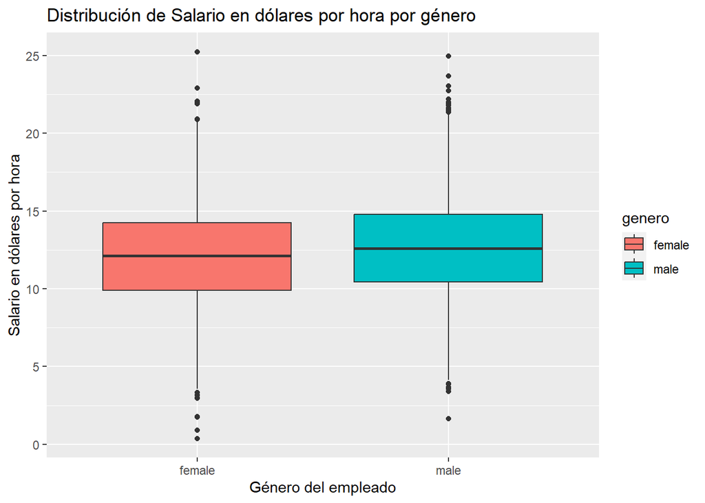

```r
ggplot(data, aes(x = genero, y = salario, fill = genero)) +
  geom_boxplot() +
  ggtitle("Distribución de Salario en dólares por hora por género") +
  xlab("Género del empleado") +
  ylab("Salario en dólares por hora")
```

### Histogramas y las densidades para la variable experiencia por genero y grado de escolaridad

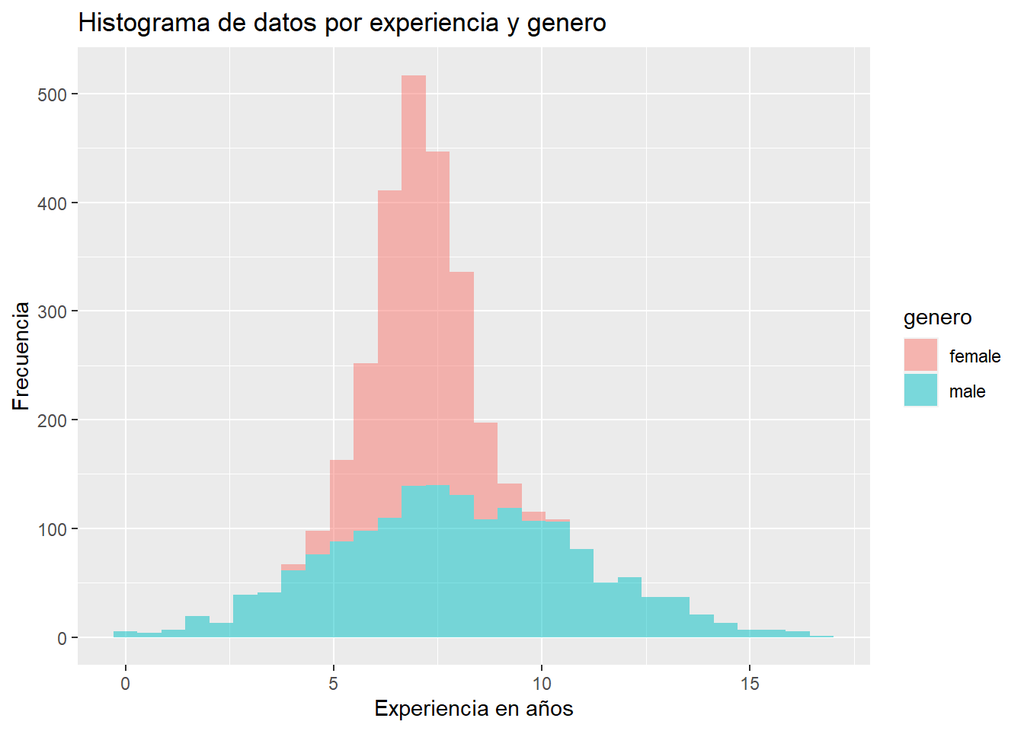

```r
ggplot(data, aes(experiencia, fill=genero))+
    geom_histogram(alpha=0.50)+
    labs(title="Histograma de datos por experiencia y genero",x="Experiencia en años", y = "Frecuencia")+
  guides(fill = guide_legend("genero"), color = FALSE)
```

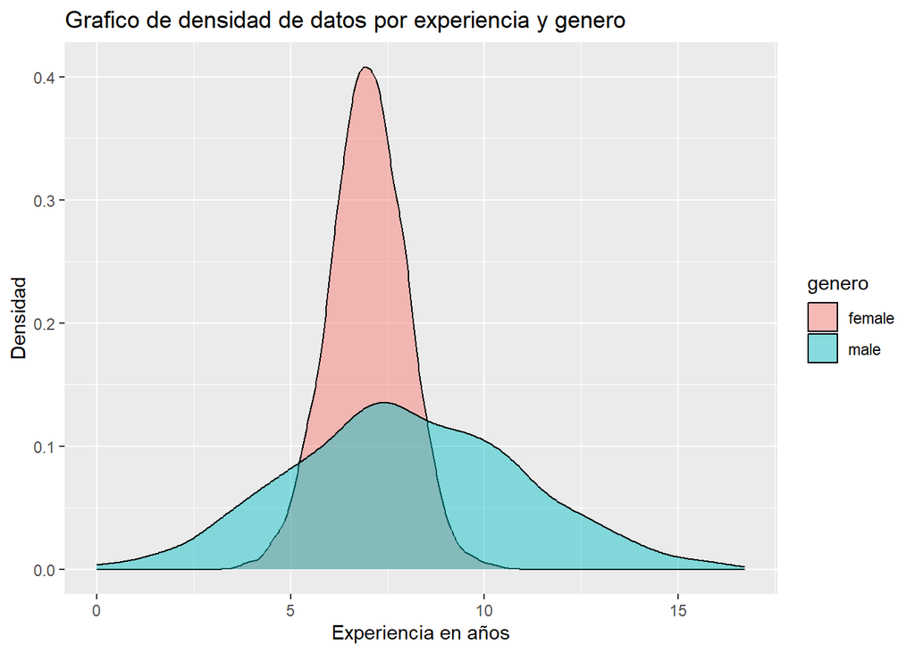

```r
ggplot(data, aes(experiencia, fill=genero))+
    geom_density(alpha=0.45)+
    labs(title="Grafico de densidad de datos por experiencia y genero",x="Experiencia en años", y = "Densidad")+
  guides(fill = guide_legend("genero"), color = FALSE)
```

En el histograma como en el grafico de densidad se observa una mayor variabilidad en la experiencia del género masculino y una mayor homogeneidad en el grupo femenino. Además, se puede observar que en ambos gráficos la forma de la distribución es levemente simétrica. Estos resultados podrían ser útiles para tomar decisiones en cuanto a la gestión de recursos humanos, como el diseño de programas de capacitación y desarrollo de habilidades, así como en la toma de decisiones en cuanto a la remuneración de los empleados en función de su género y nivel de experiencia.

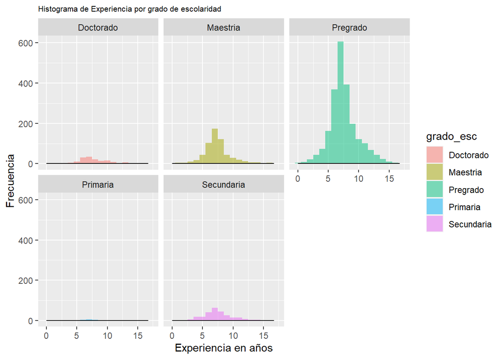

```r
  ggplot(data, aes(x = experiencia, fill = grado_esc)) +
  geom_histogram(binwidth = 1, alpha = 0.5, position = "identity") +
  facet_wrap(~grado_esc) +
  ggtitle("Histograma de Experiencia por grado de escolaridad") +
  theme(plot.title = element_text(size = 8)) +
  xlab("Experiencia en años") +
  ylab("Frecuencia") +
  geom_density(alpha = 0.5, fill = "blue")
```

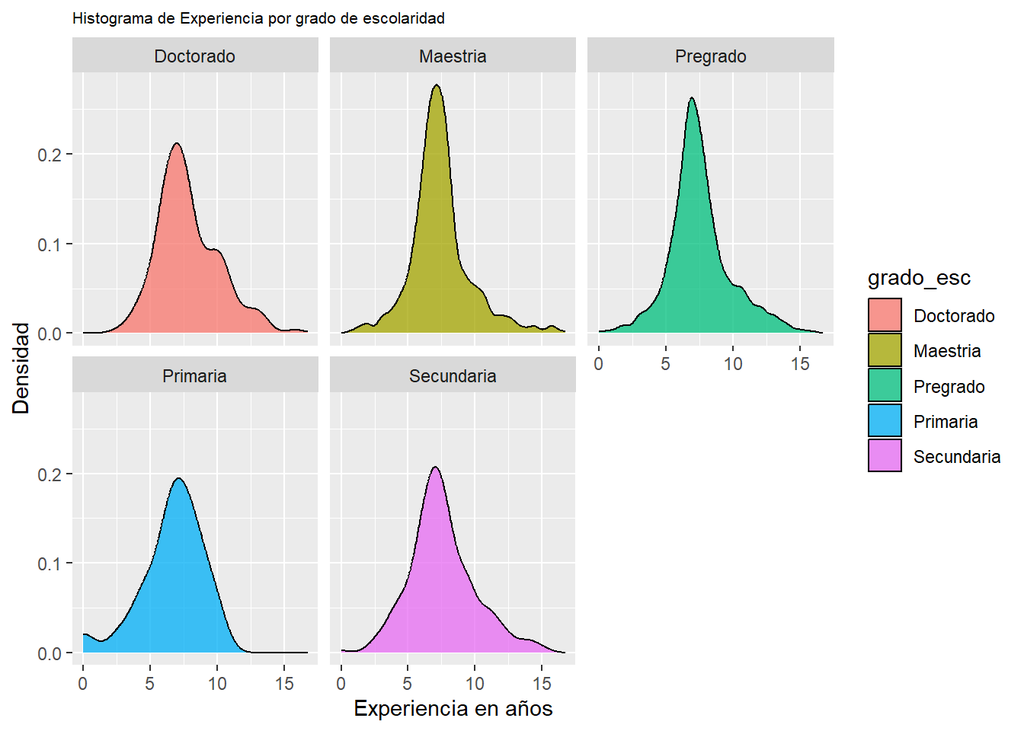

```r
  ggplot(data, aes(x = experiencia, fill = grado_esc)) +
  geom_density(alpha = 0.5, position = "identity") +
  facet_wrap(~grado_esc) +
  ggtitle("Histograma de Experiencia por grado de escolaridad") +
  theme(plot.title = element_text(size = 8)) +
  xlab("Experiencia en años") +
  ylab("Densidad") +
  geom_density(alpha = 0.5)
```

### Histogramas y las densidades para la variable salario por genero y grado de escolaridad

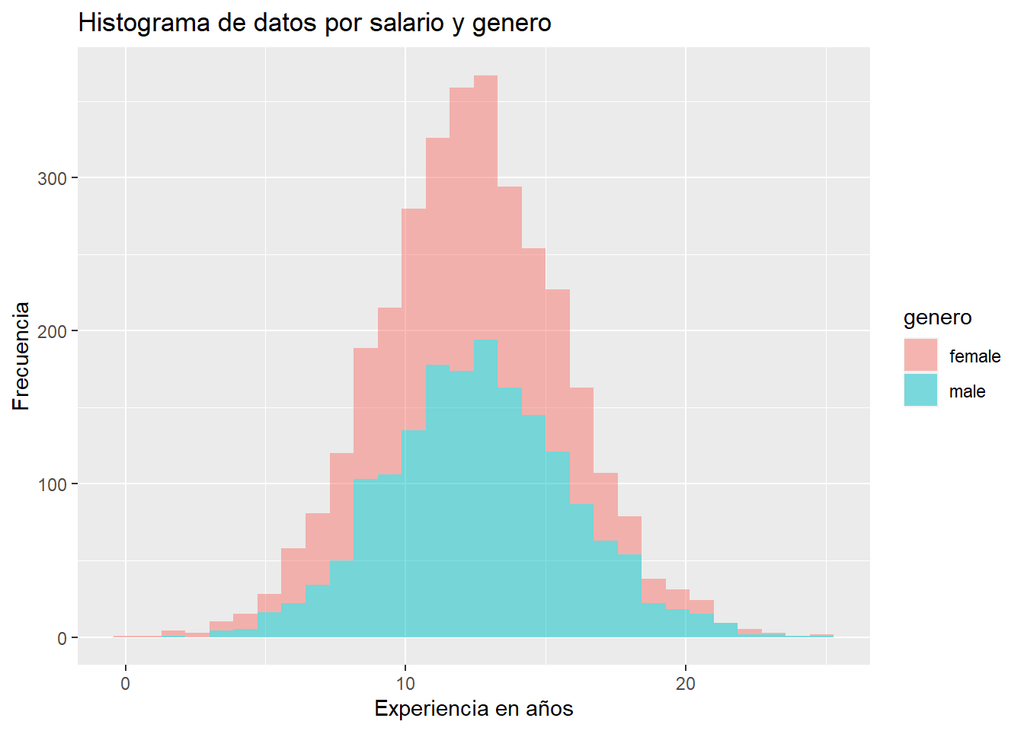

```r
ggplot(data, aes(salario, fill=genero))+
    geom_histogram(alpha=0.50)+
    labs(title="Histograma de datos por salario y genero",x="Experiencia en años", y = "Frecuencia")+
  guides(fill = guide_legend("genero"), color = FALSE)
```

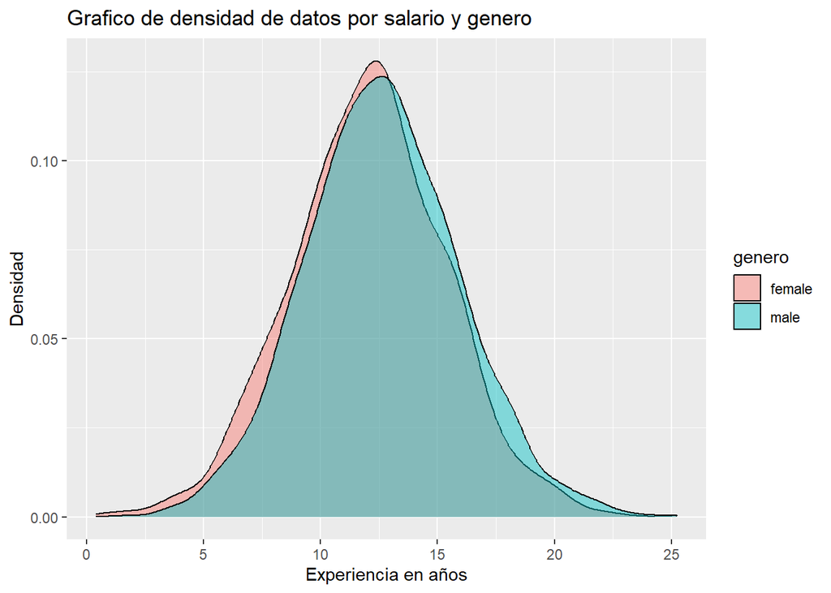

```r
ggplot(data, aes(salario, fill=genero))+
    geom_density(alpha=0.45)+
    labs(title="Grafico de densidad de datos por salario y genero",x="Experiencia en años", y = "Densidad")+
  guides(fill = guide_legend("genero"), color = FALSE)
```

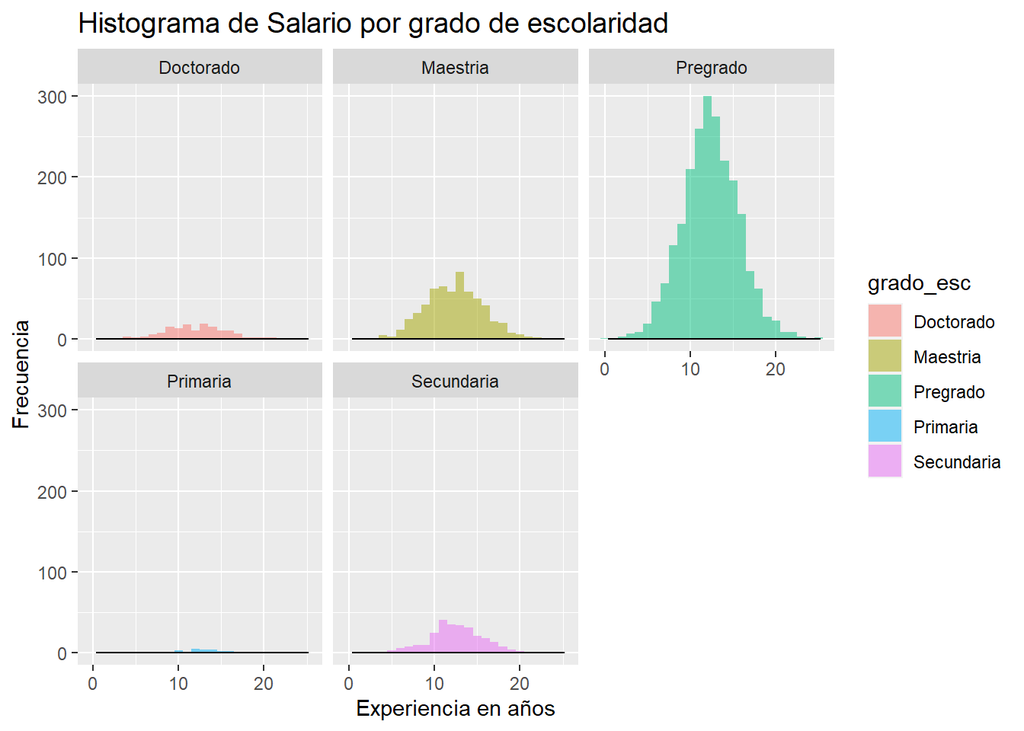

```r
  ggplot(data, aes(x = salario, fill = grado_esc)) +
  geom_histogram(binwidth = 1, alpha = 0.5, position = "identity") +
  facet_wrap(~grado_esc) +
  ggtitle("Histograma de Salario por grado de escolaridad") +
  theme(plot.title = element_text(size = 14)) +
  xlab("Experiencia en años") +
  ylab("Frecuencia") +
  geom_density(alpha = 0.5, fill = "blue")
```

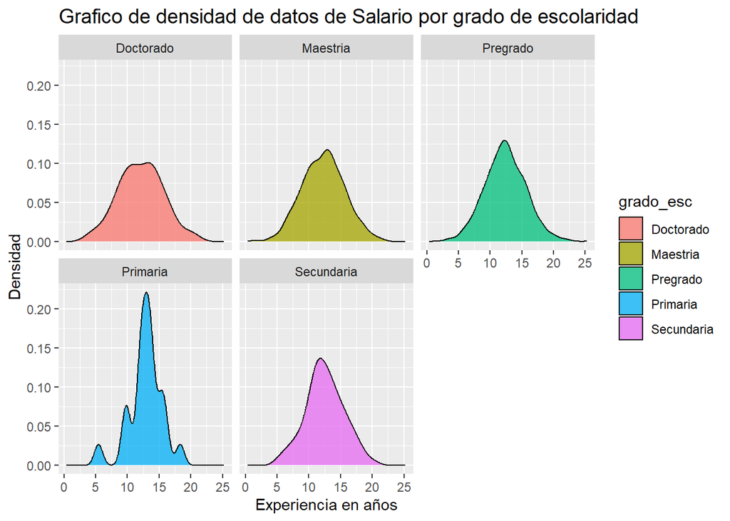

```r
  ggplot(data, aes(x = salario, fill = grado_esc)) +
  geom_density(alpha = 0.5, position = "identity") +
  facet_wrap(~grado_esc) +
  ggtitle("Grafico de densidad de datos de Salario por grado de escolaridad") +
  theme(plot.title = element_text(size = 14)) +
  xlab("Experiencia en años") +
  ylab("Densidad") +
  geom_density(alpha = 0.5)
```

En el análisis del salario por grado de escolaridad, se puede observar que la distribución de los empleados es mayor para aquellos con formación en pregrado, seguido de los que tienen una maestría. En la gráfica de densidad se observa que todas las distribuciones parecen ser normales, excepto para los empleados con grado de escolaridad primaria, ya que su distribución es asimétrica, lo que indica que los datos están sesgados. Esto prodría ser útil para planificar programas de desarrollo y capacitación para los empleados que tienen una formación educativa más baja, para ayudarles a aumentar su nivel educativo y por ende, sus posibilidades de ascenso y aumento de salario.

### QQplot para la variable experiencia por genero y grado de escolaridad

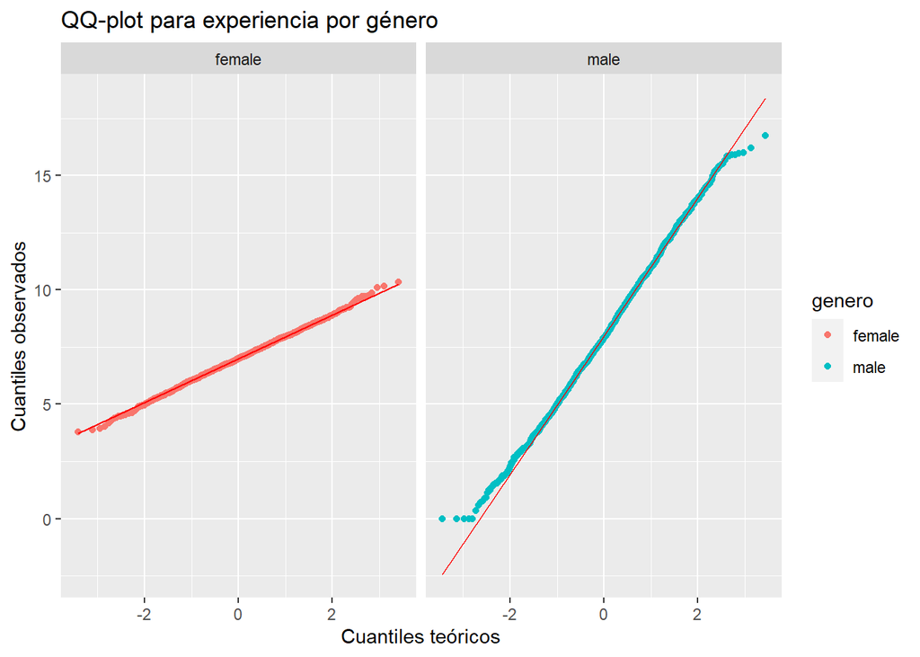

```r
ggplot(data, aes(sample = experiencia, color = genero)) +
  stat_qq() +
  facet_wrap(~genero) +
  stat_qq_line(col = "red") +
  xlab("Cuantiles teóricos") +
  ylab("Cuantiles observados") +
  ggtitle("QQ-plot para experiencia por género")
```

En el análisis del QQplot para la variable de experiencia por género, se puede observar que el gráfico sigue una línea recta QQ. Este resultado es un indicativo de que los valores aleatorios de la variable de experiencia siguen una distribución normal. La recta QQ se traza con los cuantiles teóricos en el eje x y los cuantiles observados en el eje y. Si los puntos en el gráfico caen cerca de la línea recta QQ, entonces podemos asumir que los datos siguen una distribución normal. En este caso, al seguir una línea recta, podemos concluir que la distribución de la experiencia para el genero femenino es normal y para el genero masculino no se puede concluir que sea noramal

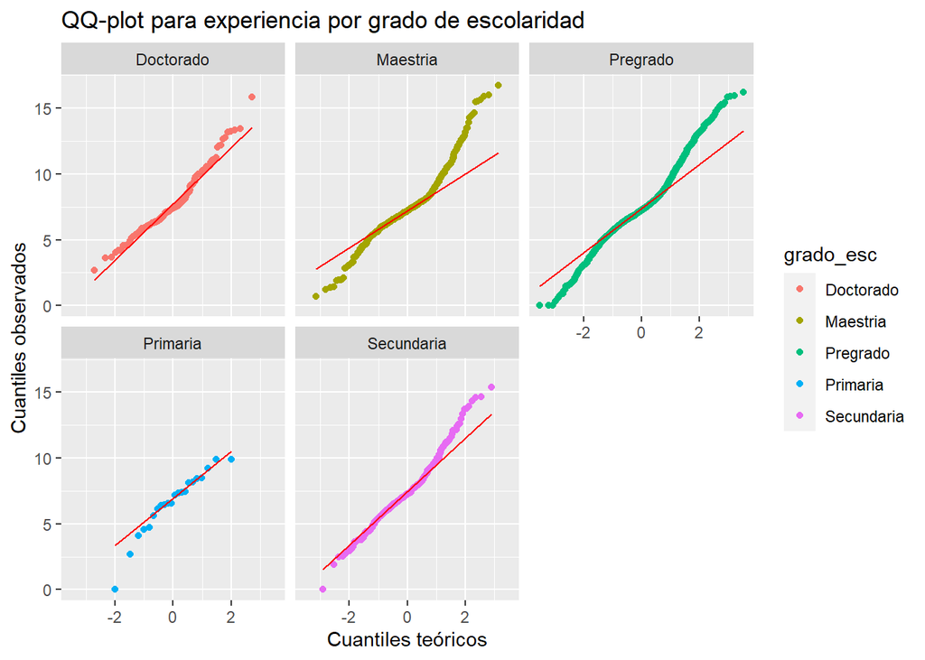

```r
ggplot(data, aes(sample = experiencia, color = grado_esc))  +
  stat_qq() +
  facet_wrap(~grado_esc) +
  stat_qq_line(col = "red") +
  xlab("Cuantiles teóricos") +
  ylab("Cuantiles observados") +
  ggtitle("QQ-plot para experiencia por grado de escolaridad")
```

En el análisis del gráfico QQ-plot para la variable experiencia por grado de escolaridad, se observa que para ninguno de los grados de escolaridad la línea del QQ-plot sigue la línea recta QQ, lo que sugiere que los valores aleatorios no siguen una distribución normal. Esta información es importante porque si se asume que los datos se distribuyen normalmente cuando en realidad no lo hacen, esto podría afectar la precisión y exactitud de los resultados obtenidos a partir de análisis estadísticos posteriores. Por lo tanto, es necesario tener en cuenta que los datos no siguen una distribución normal al tomar decisiones o realizar inferencias a partir de ellos.

### QQplot para la variable salario por genero y grado de escolaridad

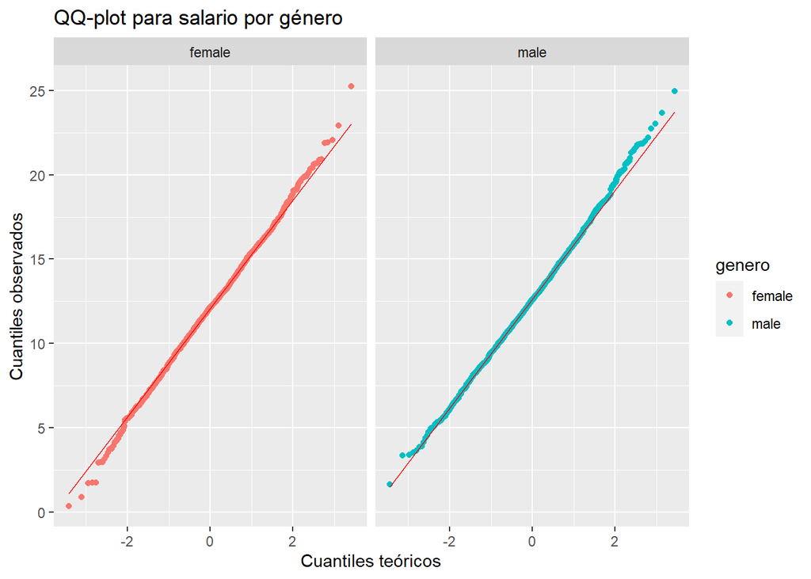

```r
ggplot(data, aes(sample = salario, color = genero)) +
  stat_qq() +
  facet_wrap(~genero) +
  stat_qq_line(col = "red") +
  xlab("Cuantiles teóricos") +
  ylab("Cuantiles observados") +
  ggtitle("QQ-plot para salario por género")
```

En el gráfico QQ-plot para la variable salario por género, podemos observar que la distribución de los datos se ajusta bastante bien a la línea recta QQ, lo que sugiere que los valores aleatorios para ambos géneros siguen una distribución normal. Esto es útil para verificar la validez de los supuestos estadísticos que se puedan hacer acerca de la variable, lo que permitirá llevar a cabo pruebas estadísticas de manera más precisa y confiable.

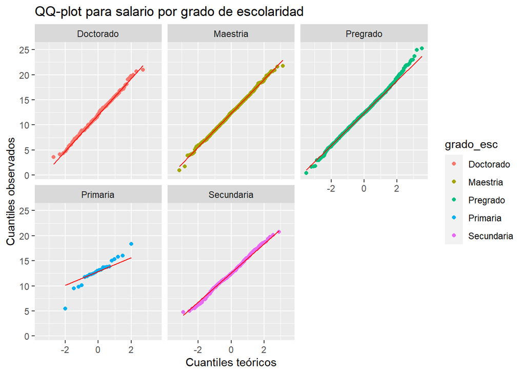

```r
ggplot(data, aes(sample = salario, color = grado_esc))  +
  stat_qq() +
  facet_wrap(~grado_esc) +
  stat_qq_line(col = "red") +
  xlab("Cuantiles teóricos") +
  ylab("Cuantiles observados") +
  ggtitle("QQ-plot para salario por grado de escolaridad")
```

En el análisis del QQ-plot para salario por grado de escolaridad, se puede observar que la distribución de los datos del grado de escolaridad primaria no sigue la línea recta QQ, lo que indica que nuestros valores aleatorios no siguen una distribución normal para ese nivel educativo en particular. Sin embargo, para los niveles educativos de doctorado, maestría, pregrado y secundaria, se puede observar que el QQ-plot sigue la línea recta QQ, lo que indica que esos valores aleatorios sí siguen una distribución normal. Este resultado puede ser útil para comprender mejor la distribución de salarios en función del grado de escolaridad y tomar decisiones informadas en términos de compensación y beneficios para los empleados.

## 2. ANÁLISIS DE NORMALIDAD DE LOS DATOS

### Tomamos el conjunto de datos por género masculino

#### Aplicar la prueba Shapiro-Wilk para la variable experiencia por género masculino

```r
shapiro.test(data_masc$experiencia)
```

```
##
##  Shapiro-Wilk normality test
##
## data:  data_masc$experiencia
## W = 0.99804, p-value = 0.03609
```

El valor p obtenido en la prueba Shapiro-Wilk para la variable experiencia en el grupo de género masculino es de 0.03609. Como este valor es menor que el nivel de significancia comúnmente utilizado de 0.05, se puede concluir que existe evidencia suficiente para rechazar la hipótesis nula de normalidad en la distribución de la variable experiencia en el grupo de género masculino. Esto significa que la distribución de la variable experiencia en este grupo no sigue una distribución normal.

#### Aplicar la prueba Shapiro-Wilk para la variable salario por género masculino

```r
shapiro.test(data_masc$salario)
```

```
##
##  Shapiro-Wilk normality test
##
## data:  data_masc$salario
## W = 0.99856, p-value = 0.1544
```

El valor p obtenido en la prueba Shapiro-Wilk para la variable salario en el grupo de género masculino es de 0.1544. Como este valor es mayor que el nivel de significancia comúnmente utilizado de 0.05, no se tiene evidencia suficiente para rechazar la hipótesis nula de normalidad en la distribución de la variable salario en el grupo de género masculino. Esto significa que la distribución de la variable salario en este grupo podría seguir una distribución normal.

### Tomamos el conjunto de datos por género femenino

#### Aplicar la prueba Shapiro-Wilk para la variable experiencia por género femenino

```r
shapiro.test(data_feme$experiencia)
```

```
##
##  Shapiro-Wilk normality test
##
## data:  data_feme$experiencia
## W = 0.99921, p-value = 0.7611
```

El valor p obtenido en la prueba Shapiro-Wilk para la variable experiencia en el grupo de género femenino es de 0.7611. Como este valor es mayor que el nivel de significancia comúnmente utilizado de 0.05, no se tiene evidencia suficiente para rechazar la hipótesis nula de normalidad en la distribución de la variable experiencia en el grupo de género femenino. Esto significa que la distribución de la variable experiencia en este grupo podría seguir una distribución normal.

#### Aplicar la prueba Shapiro-Wilk para la variable salario por género femenino

```r
shapiro.test(data_feme$salario)
```

```
##
##  Shapiro-Wilk normality test
##
## data:  data_feme$salario
## W = 0.99882, p-value = 0.3839
```

El valor p obtenido en la prueba Shapiro-Wilk para la variable salario en el grupo de género femenino es de 0.3839. Como este valor es mayor que el nivel de significancia comúnmente utilizado de 0.05, no se tiene evidencia suficiente para rechazar la hipótesis nula de normalidad en la distribución de la variable salario en el grupo de género femenino. Esto significa que la distribución de la variable salario en este grupo podría seguir una distribución normal.

## 3. PRUEBAS DE HIPÓTESIS PARA UNA MEDIA

De acuerdo al resultado del análisis de normalidad, se usa t.test o el estadístico de prueba Z para contrastar las siguientes hipótesis de acuerdo a cada variable:

##### Experiencia

H0 : µ = 7.2 H1 : µ > 7.2

##### Salario

H0 : µ = 12.8 H1 : µ < 12.8

#### Prueba de hipótesis a la variable Experiencia:

```r
t.test(data$experiencia, alternative = "greater", mu = 7.2, conf.level = 0.95)
```

```
##
##  One Sample t-test
##
## data:  data$experiencia
## t = 7.7321, df = 3293, p-value = 6.98e-15
## alternative hypothesis: true mean is greater than 7.2
## 95 percent confidence interval:
##  7.443851      Inf
## sample estimates:
## mean of x
##  7.509766
```

Como se evidencia en el resultado, el valor-p arrojó un resultado por debajo del 5% de significancia, lo que permite concluir con toda seguridad que se rechaza la hipótesis nula y se acepta la alterna, es decir que la media poblacional de la variable experiencia es mayor a 7.2 años.

#### Prueba de hipótesis a la variable salario:

```r
t.test(data$salario, mu=12.8, alternative="less")
```

```
##
##  One Sample t-test
##
## data:  data$salario
## t = -7.5922, df = 3293, p-value = 2.036e-14
## alternative hypothesis: true mean is less than 12.8
## 95 percent confidence interval:
##      -Inf 12.45653
## sample estimates:
## mean of x
##  12.36151
```

Dado que el resultado del valor-p es inferior al 5% de significancia, concluimos que la media poblacional de la variable salario es inferior a 12.8 dólares la hora

## 4. PRUEBAS PARA LA DIFERENCIA DE MEDIAS

De acuerdo al resultado del análisis de normalidad, usar t.test (verificar primero la igualdad o diferencia de varianzas) o el estadístico de prueba Z para contrastar las siguientes hipótesis:

#### 1) El salario promedio por hora de los hombres difiere que el de las mujeres y, de ser posible, determinar de cuánto es dicha diferencia.

##### Primero comparamos las varianzas:

σ2H / σ2M = 1

σ2H / σ2M <> 1

```r
var.test(data_masc$salario, data_feme$salario, alternative = "two.sided", ratio = 1, conf.level = 0.95)
```

```
##
##  F test to compare two variances
##
## data:  data_masc$salario and data_feme$salario
## F = 0.98386, num df = 1724, denom df = 1568, p-value = 0.7411
## alternative hypothesis: true ratio of variances is not equal to 1
## 95 percent confidence interval:
##  0.8930251 1.0837014
## sample estimates:
## ratio of variances
##          0.9838649
```

El valor-p es del 74%, por lo tanto se concluye que no hay suficiente evidencia para afirmar que las varianzas de los salarios de los hombres y mujeres son diferentes.

##### Prueba de hipotesis para la diferencia de medias en la variable salario:

H1 : µH − µM <> 0

```r
d0=0.35
t.test(x = data_masc$salario, y = data_feme$salario, alternative = "two.sided", mu=d0, var.equal = TRUE, paired = FALSE)
```

```
##
##  Two Sample t-test
##
## data:  data_masc$salario and data_feme$salario
## t = 2.0055, df = 3292, p-value = 0.04499
## alternative hypothesis: true difference in means is not equal to 0.35
## 95 percent confidence interval:
##  0.3551627 0.8069642
## sample estimates:
## mean of x mean of y
##  12.63828  12.05721
```

#### 2) Es mayor la experiencia de los hombres que de las mujeres? Determinar en cuánto es mayor.

##### Primero comparamos las varianzas:

σ2H / σ2M = 1

σ2H / σ2M <> 1

```r
var.test(x = data_masc$experiencia, y=data_feme$experiencia, alternative = "two.sided", ratio = 1)
```

```
##
##  F test to compare two variances
##
## data:  data_masc$experiencia and data_feme$experiencia
## F = 9.1887, num df = 1724, denom df = 1568, p-value < 2.2e-16
## alternative hypothesis: true ratio of variances is not equal to 1
## 95 percent confidence interval:
##   8.340344 10.121151
## sample estimates:
## ratio of variances
##           9.188736
```

Valor-p por debajo del 5%, por lo tanto las varianzas son diferentes.

##### Prueba de hipotesis para la diferencia de medias en la variable experiencia:

H0 : µH − µM = 0

H1 : µH − µM > 0

```r
d0 = 0.885
t.test(x=data_masc$experiencia, y=data_feme$experiencia, alternative = "greater", var.equal = FALSE, mu = d0, paired = FALSE)
```

```
##
##  Welch Two Sample t-test
##
## data:  data_masc$experiencia and data_feme$experiencia
## t = 1.656, df = 2127.7, p-value = 0.04894
## alternative hypothesis: true difference in means is greater than 0.885
## 95 percent confidence interval:
##  0.8857833       Inf
## sample estimates:
## mean of x mean of y
##  7.990742  6.980969
```

## 5. COEFICIENTE DE CORRELACION

Se determina el coeficiente de correlación, discrimando entre hombres y mujeres, para la relación existente entre la experiencia (variable explicativa) y el salario por hora (variable dependiente); También se halla el coeficiente de determinación muestral. Se Plantea una prueba de hipótesis que permita contrastar ρ = 0 con ρ > 0 y una prueba aplicando la transformación de Fisher para contrastar ρ = ρ0 con ρ > ρ0 para un ρ0 adecuado.

#### Realizamos prueba de normalidad para hombres en la variable experiencia y salario:

```r
shapiro.test(data_masc$salario)
```

```
##
##  Shapiro-Wilk normality test
##
## data:  data_masc$salario
## W = 0.99856, p-value = 0.1544
```

```r
shapiro.test(data_masc$experiencia)
```

```
##
##  Shapiro-Wilk normality test
##
## data:  data_masc$experiencia
## W = 0.99804, p-value = 0.03609
```

Al realizar las pruebas de normalidad a las variables salario y experiencia al género masculino, se identifica que el valor-p para la variable experiencia es inferior al 5%, por lo tanto, no hay evidencias suficientes para afirmar que hay normalidad en los datos de dicha variable. Teniendo en cuenta que la variable experiencia es asimetrica, para el análisis de correlación, usaremos el coefieciente de correlación de rango o de spearman:

```r
r = cor(data_masc$experiencia, data_masc$salario, method = "spearman")
r
```

```
## [1] 0.01463081
```

##### Coeficiente de determinación muestral

```r
r^2
```

```
## [1] 0.0002140606
```

Según el análisis de correlación, se evidencia que para el género masculino, existe una correlación positiva muy debil, por lo tanto, se puede concluir que hay ausencia de una relación lineal, lo que significa que los cambios en una variable no están fuertemente relacionados con los cambios en la otra; y según el coeficiente de de determinación muestral indica que el modelo de regresión lineal utilizado no explica de manera significativa la variabilidad de la variable salario a partir de la variable experiencia.

#### Realizamos prueba de normalidad para mujeres en la variable experiencia y salario:

```r
shapiro.test(data_feme$salario)
```

```
##
##  Shapiro-Wilk normality test
##
## data:  data_feme$salario
## W = 0.99882, p-value = 0.3839
```

```r
shapiro.test(data_feme$experiencia)
```

```
##
##  Shapiro-Wilk normality test
##
## data:  data_feme$experiencia
## W = 0.99921, p-value = 0.7611
```

Según las pruebas de normalidad en las variables experiencia y salario para el género femenino, se evidencia que el valor-p nos da un resultado por encima del 5%, lo que significa que las variables tienen una distrubición normal. Para el análisis de correlación, usaremos el coefieciente de correlación de pearson:

```r
r = cor(data_feme$experiencia, data_feme$salario, method = "pearson")
r
```

```
## [1] -0.03333489
```

Coeficiente de determinación muestral

```r
r^2
```

```
## [1] 0.001111215
```

#### hipótesis que permite contrastar si:

H0: ρ = 0

H1: ρ > 0

##### Prueba de normalidad para experiencia y salario

```r
shapiro.test(data$experiencia)
```

```
##
##  Shapiro-Wilk normality test
##
## data:  data$experiencia
## W = 0.96315, p-value < 2.2e-16
```

```r
shapiro.test(data$salario)
```

```
##
##  Shapiro-Wilk normality test
##
## data:  data$salario
## W = 0.99911, p-value = 0.09668
```

Al realizar la prueba de normalidad con toda la población en la variable experiencia, se evidencia que el valor-p arroja un resultado por debajo del 5%, razón por la cual se concluye que no existen suficientes evidencias para determinar una normalidad en los datos de la variable experiencia. De acuero con lo anterior se realiza una prueba de hipótesis con el coefieciente de correlación de rangos o de spearman:

```r
cor.test(data$experiencia, data$salario, method = "spearman", alternative = "greater")
```

```
##
##  Spearman's rank correlation rho
##
## data:  data$experiencia and data$salario
## S = 5857816785, p-value = 0.17
## alternative hypothesis: true rho is greater than 0
## sample estimates:
##        rho
## 0.01663151
```

Según el resultado del valor-p, se puede concluir que no hay evidencia suficiente para afirmar que existe una correlación significativa entre la experiencia y el salario en los datos analizados.

##### Prueba aplicando la transformación de Fisher para contrastar si:

H0: ρ = ρ0

H1: ρ > ρ0 para un ρ0 adecuado.

```r
r = cor(data$experiencia, data$salario)
r
```

```
## [1] 0.02666758
```

```r
V = 1/2*log((1+r)/(1-r))
n = length(data$salario)

rho_0 = 0

Z = (V - 1/2*log((1+rho_0)/(1-rho_0))) / (1/sqrt(n-3))

valorp = pnorm(Z, lower.tail = FALSE)
valorp
```

```
## [1] 0.06298263
```

Con una significancia del 5% podemos concluir que no hay evidencias suficientes para aceptar que existen relaciones significativas entre las variables experiencia y salario.

## 6. ANÁLISIS DE INDEPENDENCIA

Aplicamos la prueba chi-cuadrado para datos categóricos a fin de determinar si existe dependencia entre el grado de escolaridad y el género, posteriormente graficamos.

#### Creamos tabla de contiengencia:

```r
tabla_contingencia <- table(data$grado_esc, data$genero)
tabla_contingencia
```

```
##
##              female male
##   Doctorado      79   71
##   Maestria      329  274
##   Pregrado     1067 1181
##   Primaria        4   18
##   Secundaria     90  181
```

#### Luego, podemos aplicar la prueba chi-cuadrado

```r
resultado_chi_cuadrado <- chisq.test(tabla_contingencia, correct = FALSE)
estadistico_chi_cuadrado <- resultado_chi_cuadrado$statistic
valor_p <- resultado_chi_cuadrado$p.value
estadistico_chi_cuadrado;
```

```
## X-squared
##  43.40004
```

```r
valor_p
```

```
## [1] 8.547277e-09
```

#### graficamos la tabla de contingencia

[figure not shown]

```r
barplot(tabla_contingencia, beside = TRUE, legend = rownames(tabla_contingencia), col = c("red", "blue"),
        main = "Gráfico de barras de género y grado de escolaridad",
        xlab = "Género",
        ylab = "Frecuencia")
```

El valor de la prueba chi-cuadrado obtenido es de 43.40004 y el valor p es de 8.547277e-09, lo cual indica que hay suficiente evidencia para rechazar la hipótesis nula de independencia entre el grado de escolaridad y el género. Esto sugiere que existe una relación significativa entre estas dos variables categóricas en la población de la cual se extrajo la muestra.